# AIMS_Hydroshare

Tyler Moore

2026-08-11

## Introduction

The purpose of this report is an audit of the coverage of data collected for the AIMS stream intermittency (STIC) project. The main focus of coverage is that is the percentage of days in a given year that each collection site reported data versus having no reported data. Additionally data gaps of more than 2 weeks were flagged for further investigation.

## Data

Data was downloaded from the [Hydroshare Website](https://www.hydroshare.org/home/) from both publicly available data and some non-public-facing datasets. All data were stored in a local folder.

One change was made in the data file for the data from the Oka’ Yanahli (OK) site in order to make reading the data simpler. The column name for site ID was updated from “siteID” to “siteId” to match all other datasets being analyzed.

Once all the data had been read in I then began to process the data. From the file names I extracted the region and watershed where the data was collected. From the datetime information I extracted the year and date. As the primary focus was on days with/without coverage I only checked to see if any data was collected on any given day. If there was any data present it was considered as coverage.

While processing the data I decided to use the calculate the percentage of coverage for the year using the entire year as the denominator, ignoring the start and end dates of data collection. This decision was made as the goal was to calculate percentage of coverage for the year of data and not percentage of coverage during the collection process.

The following table is the percentage of the year where there is at least one data point recorded during the 24 hour date.

|  | siteId | region | watershed | 2021 | 2022 | 2023 | 2024 | 2025 |
| --- | --- | --- | --- | --- | --- | --- | --- | --- |
| 1 | 01M01 | GP | KNZ | 24.4 | 51.5 | 91.2 | 99.2 | 81.4 |
| 2 | 01M02 | GP | KNZ | 41.1 | 96.2 | 95.6 | 99.2 | 81.4 |
| 3 | 01M03 | GP | KNZ | 61.9 | 99.7 | 76.4 | 100 | 81.4 |
| 4 | 01M04 | GP | KNZ | 59.5 | 54.8 | 91.2 | 38.5 | 72.9 |
| 5 | 01M05 | GP | KNZ | 59.5 | 3.3 | 19.2 | 38.5 | 0 |
| 6 | 01M06 | GP | KNZ | 59.5 | 99.7 | 95.6 | 99.2 | 81.4 |
| 7 | 01S01 | GP | KNZ | 0 | 0 | 83 | 0 | 0 |
| 8 | 02M01 | GP | KNZ | 61.9 | 48.2 | 76.4 | 60.7 | 18.1 |
| 9 | 02M02 | GP | KNZ | 61.9 | 99.7 | 95.3 | 99.2 | 81.4 |
| 10 | 02M03 | GP | KNZ | 61.9 | 48.2 | 76.4 | 60.7 | 18.1 |

[output cut: 325 more lines]

Using the Percentage of Coverage Data from above I then created a heatmap for each watershed to present a visualization of the data coverage percentages for each site within its watershed. White spaces in the heatmap indicate no data collected during that year.

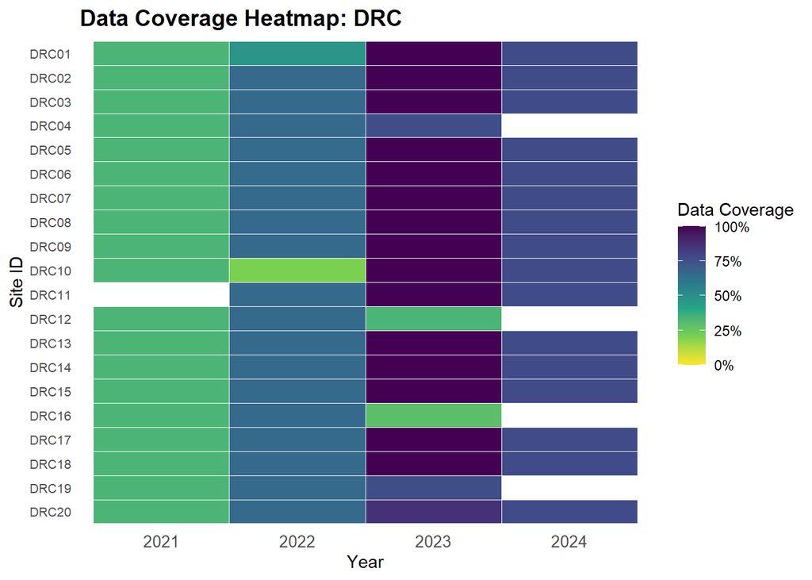

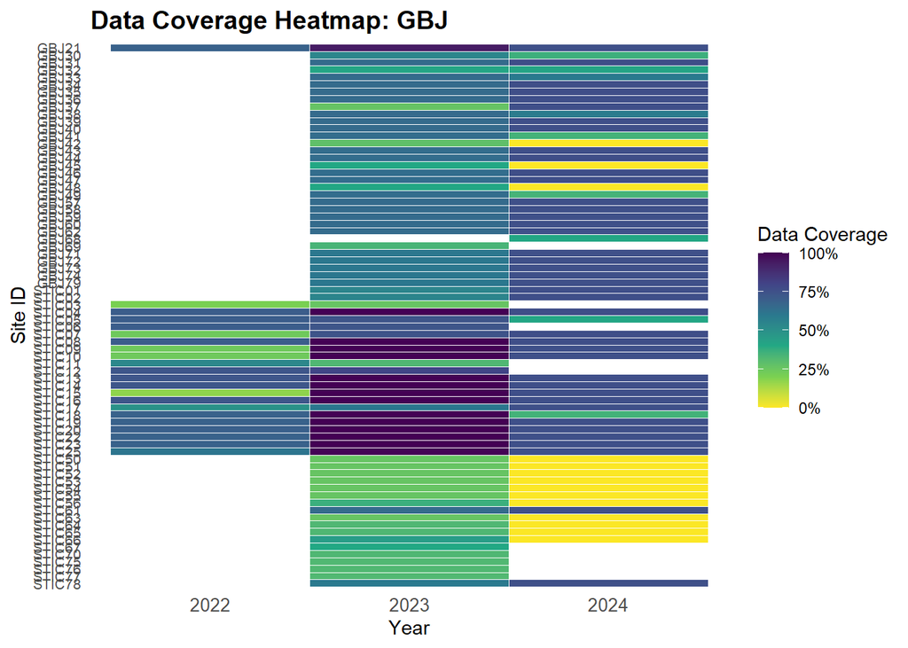

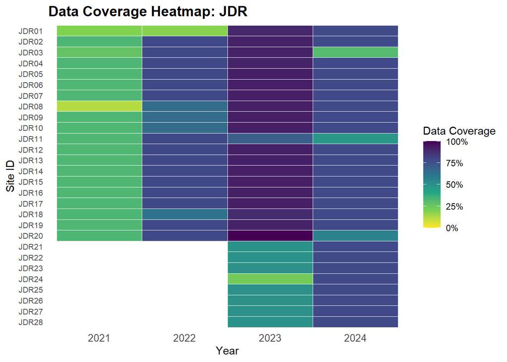

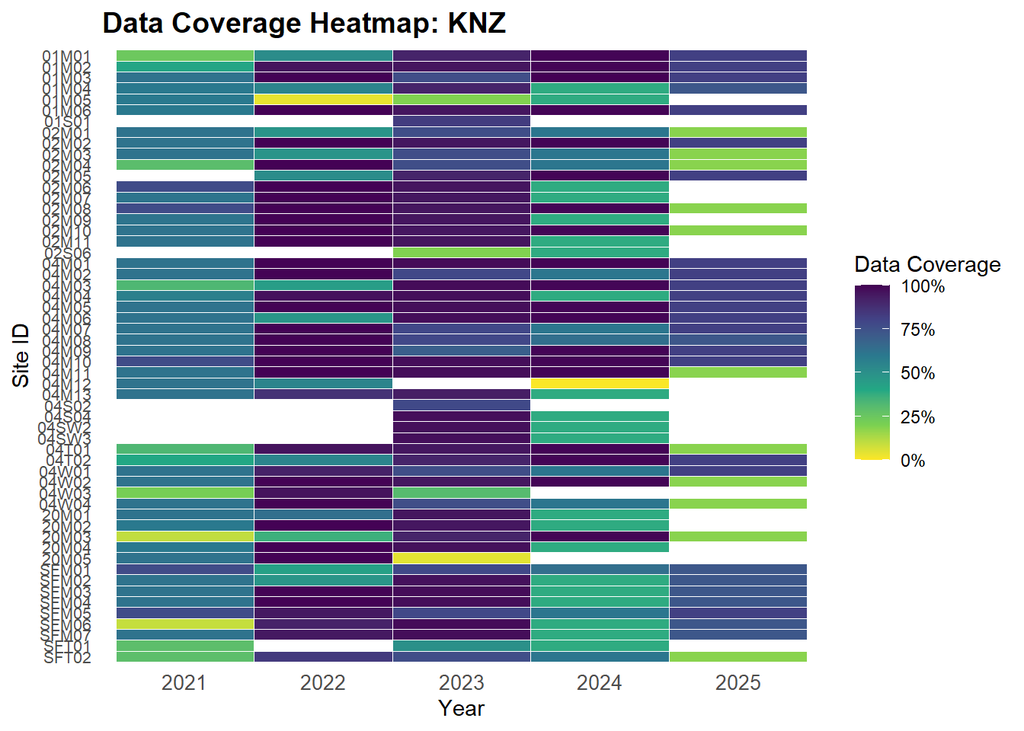

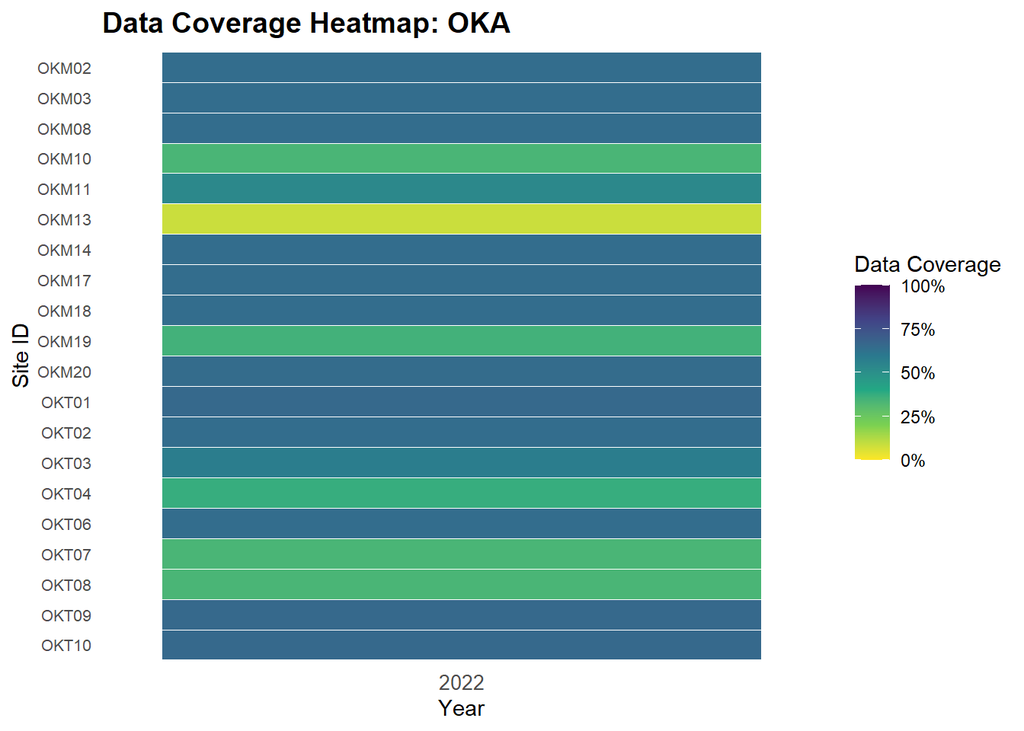

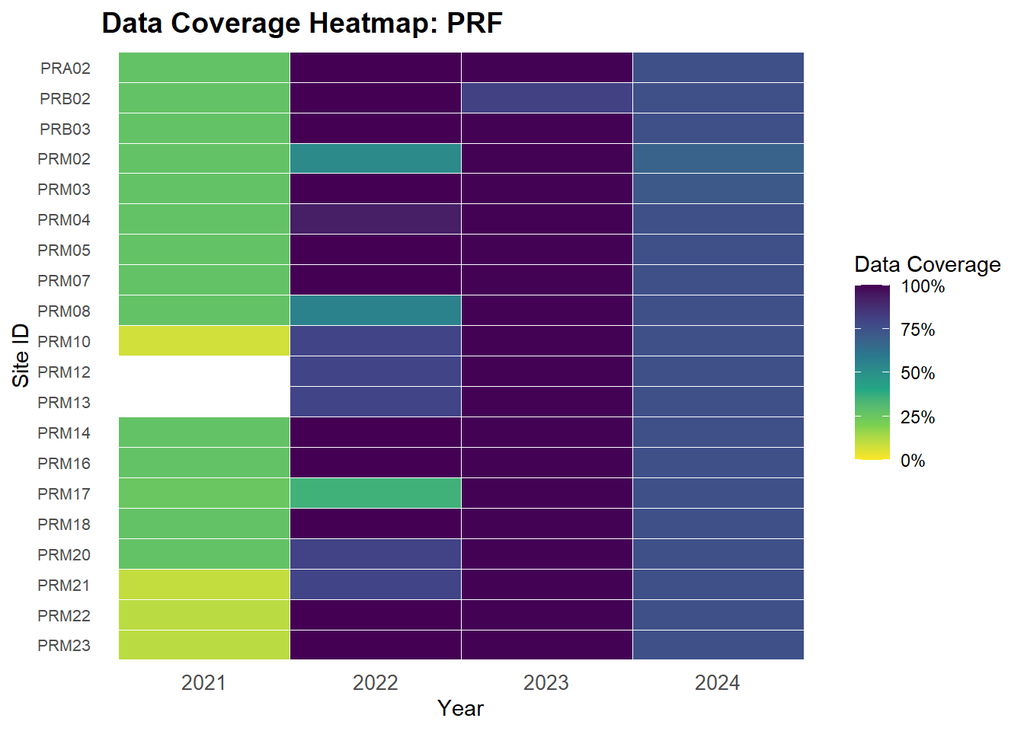

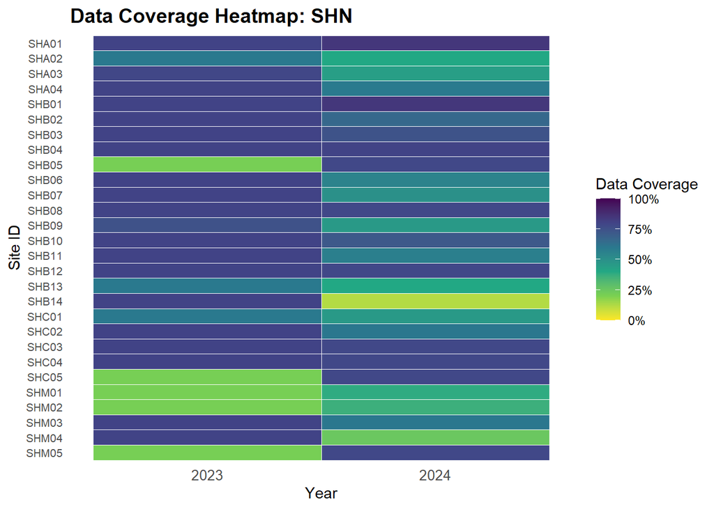

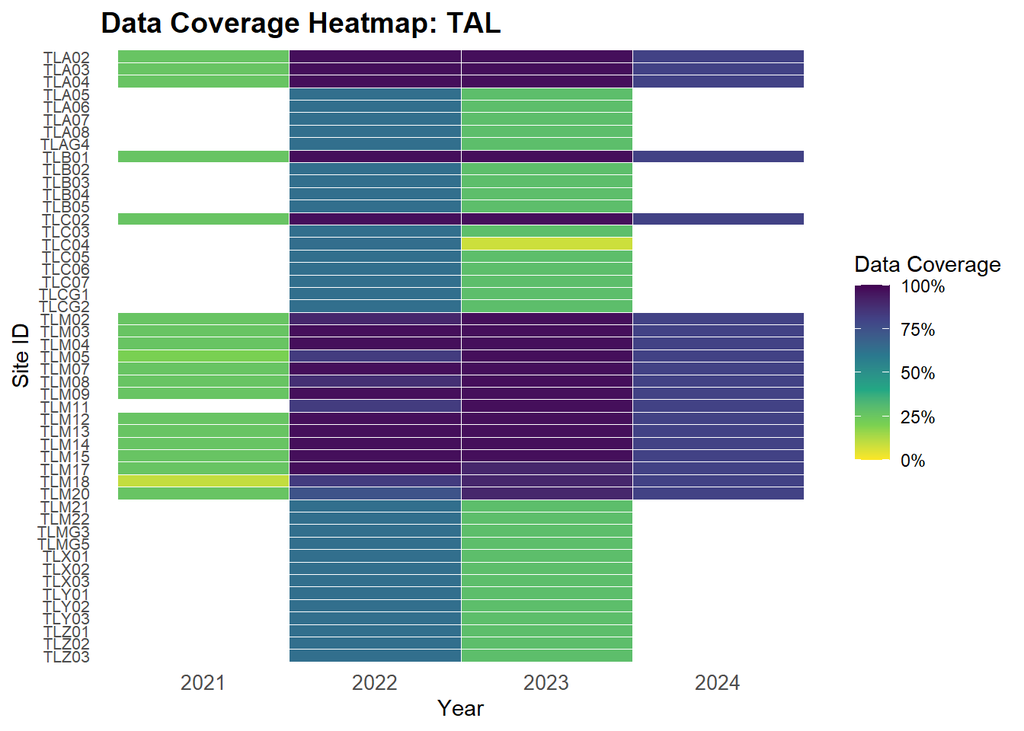

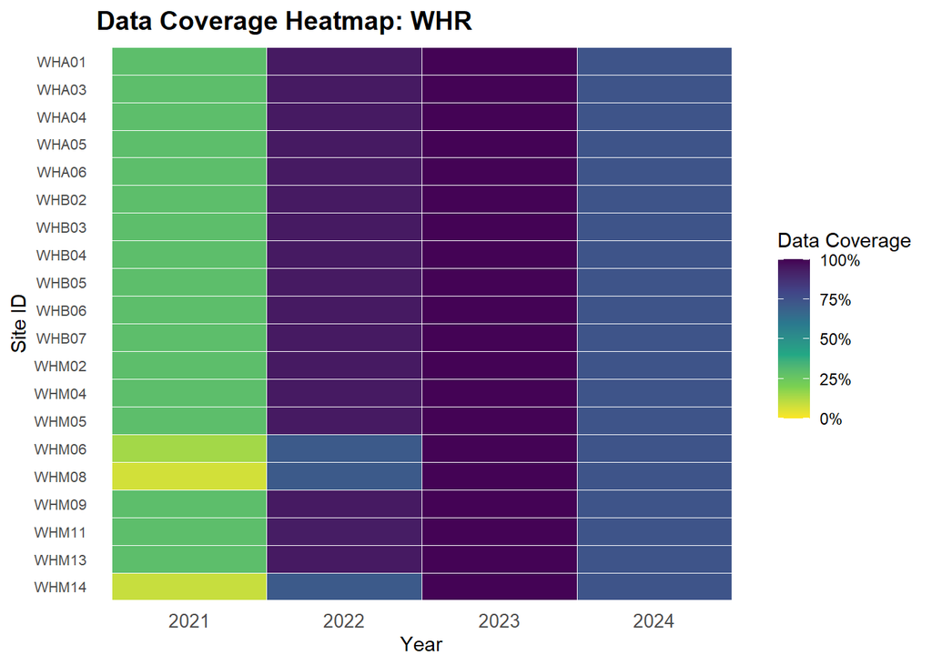

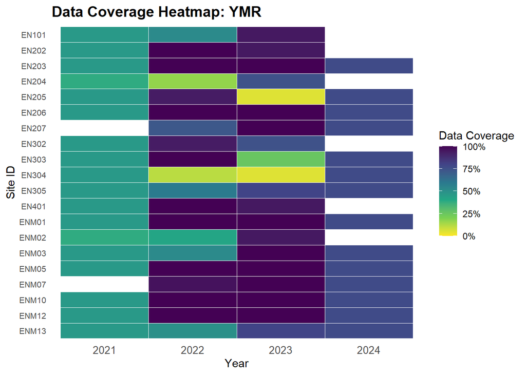

To ensure the consistency of data we were interested in breaks in data collection where the gaps was larger than 14 days. The following table consists of time frames for each data collection site where there are gaps in the data in excess of 14 days, meaning no data was reported during any point of the day for 14 days. This does mean that it is possible gaps of 14 days (or more than 336 hours) may not be flagged if the gap began early in a day and ended late on a date 14 days later. The start date of the data gap is listed as well as the end date.

|  | siteId | watershed | gap_start | gap_end | days_missing |
| --- | --- | --- | --- | --- | --- |
| 1 | 01M01 | KNZ | 2021-08-16 | 2022-01-14 | 151 |
| 2 | 01M01 | KNZ | 2022-07-20 | 2023-01-27 | 191 |
| 3 | 01M02 | KNZ | 2021-10-16 | 2022-01-14 | 90 |
| 4 | 01M03 | KNZ | 2023-10-16 | 2024-01-01 | 77 |
| 5 | 01M04 | KNZ | 2022-07-20 | 2023-01-27 | 191 |
| 6 | 01M04 | KNZ | 2024-05-20 | 2025-02-01 | 257 |
| 7 | 01M05 | KNZ | 2022-01-12 | 2023-10-23 | 649 |
| 8 | 02M01 | KNZ | 2022-01-12 | 2022-07-21 | 190 |
| 9 | 02M01 | KNZ | 2023-10-16 | 2024-05-24 | 221 |
| 10 | 02M03 | KNZ | 2022-01-12 | 2022-07-21 | 190 |

[output cut: 223 more lines]